# Bagging and Random Forest

Based on the lecture of [Edward Malthouse](https://www.youtube.com/watch?v=TlHd6Z7xQHY)

# Motivation

The random forest is an algorithm that consists on predicting the results using many random small trees to calculate the mean of their prediction (for a regression problem) or the maximum count for a classification problem. It was first introduced in [Breiman (2001)](https://link.springer.com/content/pdf/10.1023%2FA%3A1010933404324.pdf).

## Trees are unstable

- Trees are easy to interpret but very unstable and depend highly on the training sample.

For example, we use two different random samples of 150 values from the initial 200 rows of *algae* for training and fit trees for each of them.

How to random sample in R: One option is to use function *sample*. For example, we choose a sample of size 3 from the sequence 1, 2, 3, …, 10 (without replacement)

```r
set.seed(42)
sample(1:10, 3)
```

```
## [1]  1  5 10
```

Back to our problem, we pick two samples of 150 values (randomly chosen) and plot their values. As we can see in the figure below, the concentration of *a1* is often different for Sample 1 (red dots) and Sample 2 (blue dots).

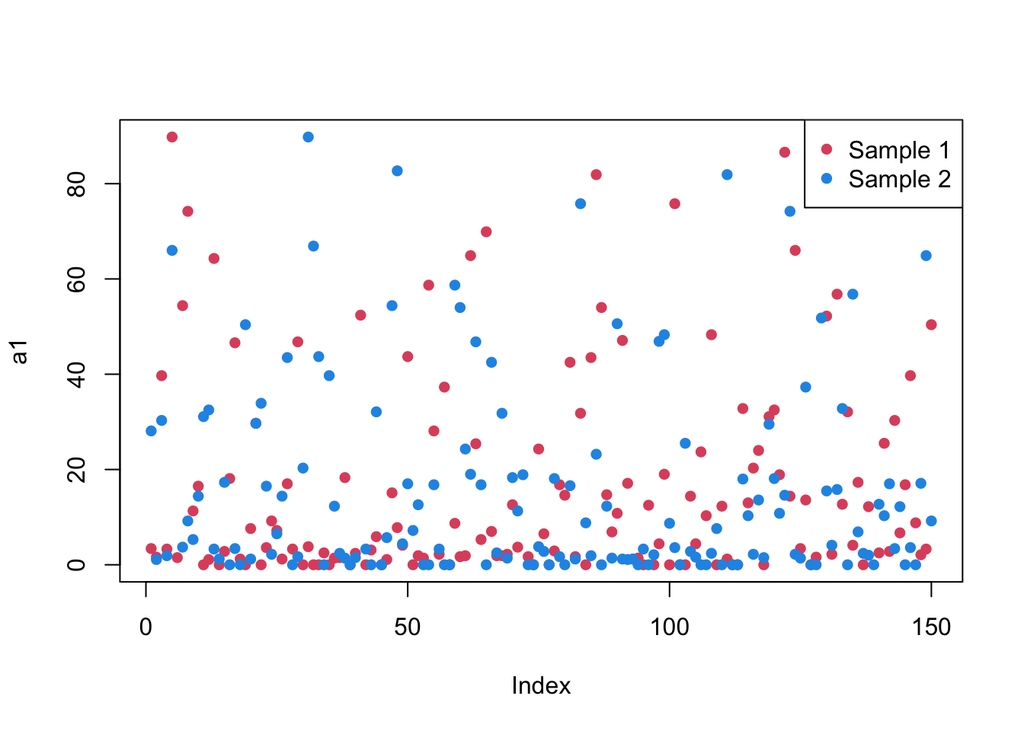

```r
library(DMwR2)
data(algae, package ="DMwR2")
algae <- algae[-manyNAs(algae, 0.2),]
clean.algae <- knnImputation(algae, k = 10)
algae1 <- clean.algae[sample(1:200, 150), 1:12 ]
algae2 <- clean.algae[sample(1:200, 150), 1:12]
plot(algae1$a1, ylab ="a1", col=2, pch=16)
points(algae2$a1, col=4, pch=16)
legend("topright", c("Sample 1", "Sample 2"), col=c(2, 4),  pch=16)
```

Now, we obtain one tree for each of the samples and plot the result. In the figure below, we can see that the two trees are very different. Not even the top node is the same. Only because they were created with two samples of the **same** dataset.

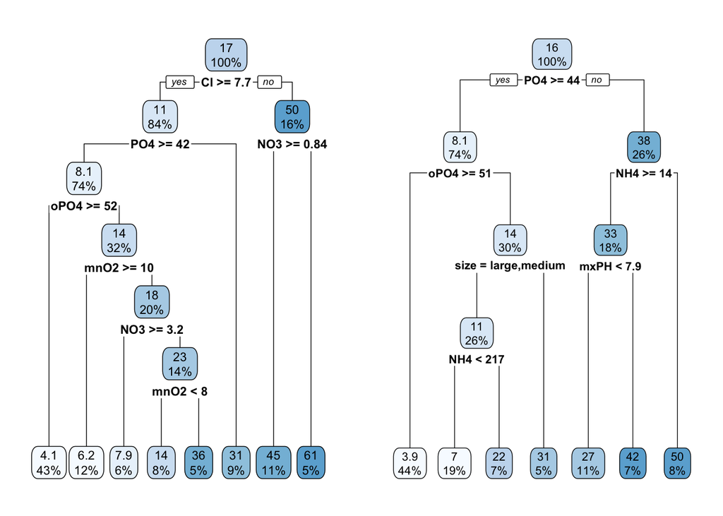

```r
library(rpart)
library(rpart.plot)
a1.rpart1 <- rpart(a1~., data = algae1)
a1.rpart2 <- rpart(a1~., data = algae2)
par(mfrow = c(1, 2))
rpart.plot(a1.rpart1)
rpart.plot(a1.rpart2)
```

```r
par(mfrow = c(1,1))
```

This will affect their prediction too. In the figure below, we compare display graphically the real values of concentration of *a1* from file *algae.sols* (black dots) and their predictions with Sample 1 (red dots) and Sample 2 (blue dots).

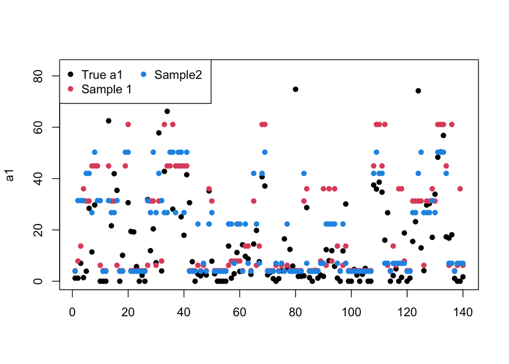

```r
plot(algae.sols$a1, ylab = "a1", xlab="", pch = 16)
points(predict(a1.rpart1, newdata = test.algae), col=2, pch=16)
points(predict(a1.rpart2, newdata = test.algae), col=4, pch=16)
legend("topleft", c("True a1", "Sample 1", "Sample2"), col=c(1,2, 4), pch=16, ncol=2)
```

# Bagging

One of the key elements of the random forest algorithm is **bagging**. Bagging is a sampling technique, also called bootstrap aggregation, that consists on randomly picking several training samples with replacement and average the estimates of any given algorithm. The idea is that obtaining the average of many imperfect estimators will result in a good estimator.

Let us see first what we mean with random sample with replacement in the chunk below.

```r
set.seed(42)
sample(1:10, replace = TRUE)
```

```
##  [1]  1  5  1  9 10  4  2 10  1  8
```

In this case, the element in position 1 would have been chosen 3 times for my training sample, the element in position 10 is chosen 2 times and for example element 3 is not chosen. We could use that sample to find a tree and keep the results. Let us do another random pick of training sample with replacement:

```r
sample(1:10, replace = TRUE)
```

```
##  [1]  7  4  9  5  4 10  2  3  9  9
```

```r
# Observations 1, 6, 8 omitted can go into testing sample
```

The bagging algorithm exploits the variation in the estimation of the model using different samples to produce a better estimate. For example, we could use bagging and estimating trees with the following algorithm.

1. Repeat the following B times:
- Draw a sample of size *n* with replacemtne from the available data
- Estimate a tree
2. Average the estimates from the B trees for the final estimate in a regression case, or take the largest count in the classification case

The main advantage of bagging is that because it picks many different samples of the training set, then the final model does not overfit the data and it is better for prediction/forecast of other values.

### Simulation of bagged tree estimate

Let us use an example to motivate the functioning of the random forest. We generate a dataset $x$ and $y$.

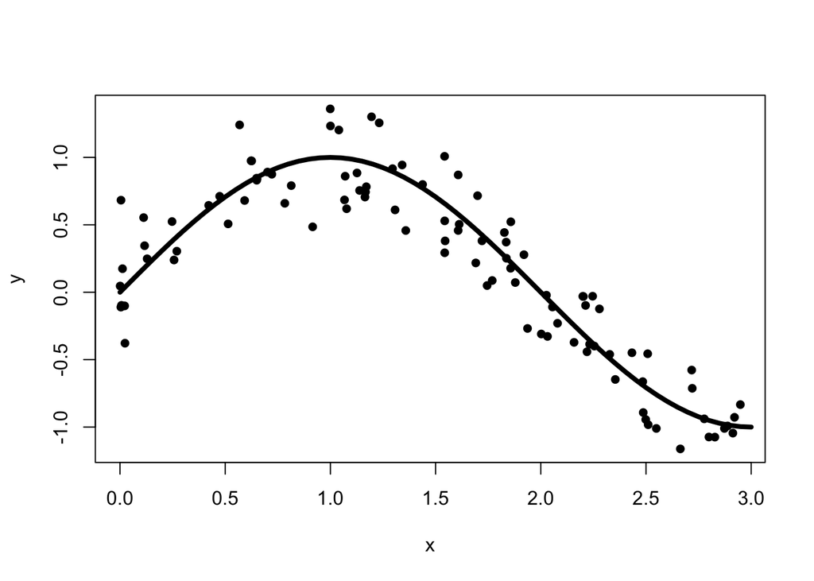

```r
n = 100
# Generate a random Uniform [0,3] variable
x=runif(n)*3
# Create an error signal from a wave
y <- sin(x*pi/2) + rnorm(n)/4
mydata <- data.frame(x=x, y=y)
# The true signal is
grid <- seq(0, 3, by = 0.05)
f <- sin(grid*pi/2)
newdata <- data.frame(x= grid, y = f)
plot(x, y, pch=16, xlab ="x", ylab = "y")
lines(grid, f, lwd = 4)
```

Let us run a bagging + tree algorithm using 20 different samples:

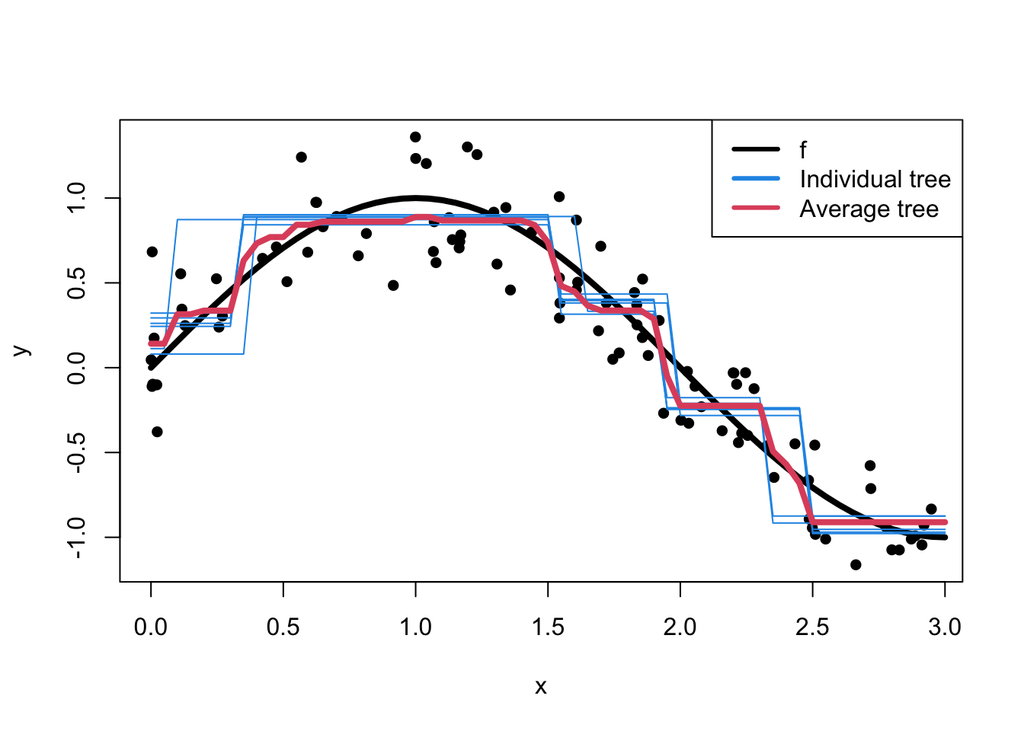

```r
plot(x, y, pch=16, xlab ="x", ylab = "y")
lines(grid, f, lwd = 4)
B <- 20
result <-numeric(length(grid))
for (i in 1:B)
{
  train <- sample(1:n, n, TRUE)
  fit <- rpart(y~x, data = mydata[train,])
  if(i <= 6)
  {# this plots only the first 6 trees prediction
    lines(grid, predict(fit, newdata = newdata), col= 4)
  }
  result <- result + predict(fit, newdata = newdata)
}
pred.20 <- result/B
lines(grid, pred.20, lwd=4, col=2)
legend ("topright", c("f", "Individual tree", "Average tree"), col = c(1, 4, 2), lty = 1, lwd = 3)
```

The figure above shows that the red line kind of lies in the middle of the blue lines. When there are disagrement between individual trees, when this is averaged (red line) we get the right answer. When we have a unstable estimator, their average is right. The problem is when there is no instability among the individual trees. That is why having a bunch of estimates that are wrong, getting the average is a good thing provided some are lower and other upper the right thing.

### Bagged tree estimate in Algae Case Study

Let us try bagging with our *clean.algae* data. We will take 100 samples and obtain the final fitted values:

```r
B = 100
a1.pred <- numeric(nrow(test.algae))
for (i in 1:B)
{
  train <- clean.algae[sample(1:200, 150, replace = TRUE), 1:12]
  a1.rpart.bag <- rpart(a1~., data=train)
  a1.pred <- a1.pred + predict(a1.rpart.bag, newdata = test.algae)
}
a1.pred <- a1.pred/B
```

Comparing the three prediction with MAE and RMSE, we can see that Bagging outperform the other two samples.

|  | MAE | RMSE |
| --- | --- | --- |
| Sample 1 | 12.28119 | 17.56636 |
| Sample 2 | 11.66632 | 16.64366 |
| Bagging | 10.15892 | 14.51271 |

# Random Forest

- The problem with simple bagging is that trees are sometime too similar, without variation, the concept does not work.
- Random forest goes a little bit further. It introduces randomness in the process of building a tree. Only a random set of predictors are considered at any given split. This means that only small trees are fit at each step which reduces the computational time. If $p$ is the number of predictors (independent variables) in our problem, at each split the random forest will take:
  - $\sqrt{p}$ number of predictors for a classification problem and
  - $p/3$ number of predictors for a regression case.
- By default, this is the algorithm that function *randomForest* in R uses in parameter *mtry*

Let us apply *randomForest* to our *clean.algae* dataset in our Algae Case Study. In this problem we have $p=10$ predictors and $p/3$ is about 3 predictors in each split. The number of trees use $B =500$ by default, but we can change that with the parameter *ntree*. These two hyperparameters *ntree* and *mtry* can be changed by the user and it can be changed to find the best values for your particular problem.

```r
library(randomForest)
algae.forest <- randomForest(a1 ~ 1 + season + size + speed + mxPH + mnO2 +
               Cl+ NO3 + NH4 + oPO4 + Chla, data = clean.algae)
algae.forest
```

```
##
## Call:
##  randomForest(formula = a1 ~ 1 + season + size + speed + mxPH +      mnO2 + Cl + NO3 + NH4 + oPO4 + Chla, data = clean.algae)
##                Type of random forest: regression
##                      Number of trees: 500
## No. of variables tried at each split: 3
##
##           Mean of squared residuals: 256.7622
##                     % Var explained: 43.76
```

## Interpretation

The random forest is difficult to interpret because it has many trees, but we can figures out which predictors (variables, features) are the most important in the prediction. This is explained with what we call *importance* and can be obtained adding parameter *importance= TRUE* in your call to the *randomForest* function. The higher the value the more importance, meaning that if we remove that predictor from our model then the purity of our trees decrease.

```r
algae.forest <- randomForest(a1 ~ 1 + season + size + speed + mxPH + mnO2 +
               Cl+ NO3 + NH4 + oPO4 + Chla, data = clean.algae, importance= TRUE)
importance(algae.forest)
```

```
##          %IncMSE IncNodePurity
## season -2.877795      2642.943
## size    3.304847      2080.047
## speed   4.759287      1957.074
## mxPH    5.327793      4939.344
## mnO2    1.044431      5040.606
## Cl     14.358670     16740.257
## NO3     5.663433      6201.603
## NH4    12.030281     17206.890
## oPO4   16.616943     18831.121
## Chla    7.334367      9301.832
```

The importance is shown visually:

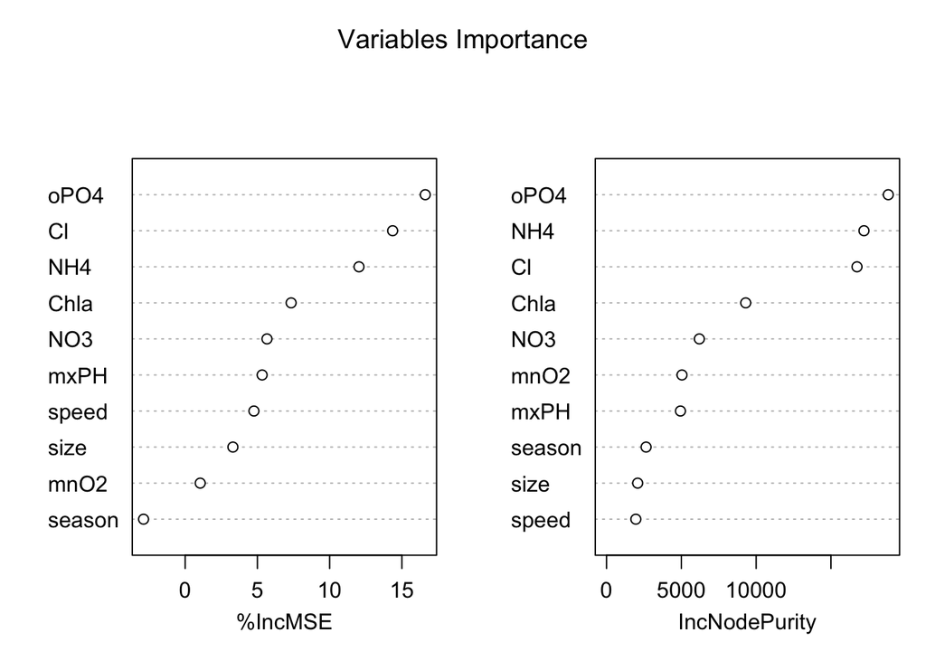

Importance plots

```r
varImpPlot(algae.forest, main ="Variables Importance")
```